# Simplified Tutorial on GIS-FA

Authors

Affiliations

Prof. Kaio Olimpio das Graças Dias

[Departamento de Biologia Geral, Universidade Federal de Viçosa](https://dbg.ufv.br/)

[Institute of Computational and Artificial Intelligence (IDATA)](https://idata.ufv.br/)

PhD Student Gabriel Blasques

[Departamento de Agronomia, Universidade Federal de Viçosa](https://daa.ufv.br/)

[Institute of Computational and Artificial Intelligence (IDATA)](https://idata.ufv.br/)

[PhD Student João Marcos Amario de Sousa](https://scholar.google.com/citations?user=fx1_ebQAAAAJ)

[Departamento de Biologia Geral, Universidade Federal de Viçosa](https://dbg.ufv.br/)

[Institute of Computational and Artificial Intelligence (IDATA)](https://idata.ufv.br/)

PhD Student Thiago Brommonschenkel

[Departamento de Biologia Geral, Universidade Federal de Viçosa](https://dbg.ufv.br/)

[Institute of Computational and Artificial Intelligence (IDATA)](https://idata.ufv.br/)

[figure not shown]

# 1 GIS-FA

This tutorial describes in detail each step of the GIS-FA analysis. The pipeline was organized into four main phases: (1) Processing of phenotypic data; (2) Processing of environmental data; (3) Prediction using PLS regression; and (4) Visualization of results through maps.

```r
library(dplyr)
library(ggplot2)
library(asreml)
library(gt)
library(grid)
library(gghighlight)
library(ggrepel)

# install.packages(c("dplyr", "ggplot2", "gt", "grid", "gghighlight", "ggrepel"))
```

# 2 Processing of phenotypic data

## 2.1 Database

At this stage, we carry out the initial preparation of the data to be used in the analyses. The goal is to ensure that the phenotypic database is properly structured, standardized, and ready for integration with the models.

The example used here refers to VCU trials in soybean. The data include 182 genotypes and 49 environments, tested in randomized complete blocks with three replications.

```r
data <- read.csv("data_soy.csv", stringsAsFactors = FALSE)
```

Before starting any analysis, it is essential to inspect the structure of the database to ensure that the variables are correctly organized and typed (e.g., factors, numeric, or character).

```r
str(data)
```

```
'data.frame':   6456 obs. of  10 variables:
 $ env  : chr  "E01" "E01" "E01" "E01" ...
 $ plant: chr  "2019-11-21" "2019-11-21" "2019-11-21" "2019-11-21" ...
 $ harv : chr  "2020-03-20" "2020-03-20" "2020-03-20" "2020-03-20" ...
 $ lat  : num  -22.2 -22.2 -22.2 -22.2 -22.2 ...
 $ lon  : num  -52.7 -52.7 -52.7 -52.7 -52.7 ...
 $ block: int  1 2 3 1 2 3 1 2 3 1 ...
 $ row  : int  32 13 13 6 18 18 27 8 8 36 ...
 $ col  : int  1 2 3 1 2 3 1 2 3 1 ...
 $ gen  : chr  "G001" "G001" "G001" "G002" ...
 $ yield: num  5525 4380 4795 5860 5185 ...
```

## 2.2 Data Transformation

At this stage, we transform the main categorical variables of the database into factor type, which is fundamental for the correct specification of the effects in mixed models fitted with the asreml package. In addition, we create four auxiliary objects to store the number of environments, the number of genotypes, the genotype names, and the environment names. These pieces of information will be used in subsequent steps of the analysis pipeline.

```r
data = transform(data,
                 gen = factor(gen),
                 block = factor(block),
                 env = factor(env))

num.env = nlevels(data$env)
num.gen = nlevels(data$gen)
name.env = levels(data$env)
geno = levels(data$gen)
```

## 2.3 Models

The idea of GIS-FA is to predict the environmental loadings of untested environments and, based on this, calculate the empirical BLUPs (EBLUPs) within each environment. Remember that, in FA, the EBLUPs are linear combinations of loadings and scores. The loadings will be predicted, but the scores used will be those previously estimated by the FA. Therefore, selecting the best FA model (i.e., the number of factors) is vital for prediction quality.

```r
asreml.options(maxit = 100, workspace = '1gb', pworkspace = '2gb')
# FA1
mod1 = asreml(fixed = yield ~ block:env + env,
              random = ~ gen:fa(env, 1),
              data = data,
              na.action = na.method(x="include", y = "include"), maxit = 50)

# FA2
mod2 = asreml(fixed = yield ~ block:env + env,
              random = ~ gen:fa(env, 2),
              data = data,
              na.action = na.method(x="include", y = "include"), maxit = 50)

# FA3
mod3 = asreml(fixed = yield ~ block:env + env,
              random = ~ gen:fa(env, 3),
              data = data,
              na.action = na.method(x="include", y = "include"), maxit = 100)


# FA4
mod4 = asreml(fixed = yield ~ block:env + env,
              random = ~ gen:fa(env, 4),
              data = data,
              na.action = na.method(x="include", y = "include"), maxit = 100)

# FA5
mod5 = asreml(fixed = yield ~ block:env + env,
              random = ~ gen:fa(env, 5),
              data = data,
              na.action = na.method(x="include", y = "include"), maxit = 100)
```

## 2.4 Selecting the appropriate model

At this stage, we use the function fa.outs(), developed by Saulo Chaves, to process the results of the Factor Analytic (FA) model fitted in asreml. This function automates important procedures, such as the rotation of factor loadings using singular value decomposition (SVD), the generation of rotated scores for genotypes, the reconstruction of the genetic variance-covariance matrix across environments, and provides essential diagnostic metrics for selecting the best FA model.

```r
load(file = 'FAMM_soy.RData')
```

```r
source("https://raw.githubusercontent.com/saulo-chaves/May_b_useful/refs/heads/main/fa_outs.R")
fa.models = list(mod1, mod2, mod3, mod4)
fa.res = lapply(fa.models, function(x) fa.outs(x, name.env = "env",
                                               name.gen = "gen"))
```

```r
diagnos = do.call(rbind,lapply(fa.res, function(x) x$diagnostics))
rownames(diagnos) = c("mod1", "mod2", "mod3", "mod4"); diagnos[,c('aic','expvar')]
```

```
          aic expvar
mod1 75892.09 53.702
mod2 75801.36 71.975
mod3 75800.93 79.960
mod4 75799.66 84.760
```

The model with four factors was the one that reached at least 80% of the explained genetic variance and presented the lowest AIC value. For these reasons, it was selected for the subsequent analyses.

After selecting the model with four factors, the corresponding results were stored in the object fa4. To ensure reproducibility of the analyses and facilitate later access to the results, we saved this object in an .RDS file. The .RDS format allows storing the complete object, preserving its internal structure (lists, matrices, data frames), which is particularly important for complex results such as those generated by fa.outs().

```r
fa4 = fa.res[[4]]
rm(mod1, mod2, mod3, fa.models, fa.res)

#saveRDS(fa4, file = "/Users/thiagobrommonschenkel/Downloads/Curse_GIS-FA1.0/fa4.rds")
```

## 2.5 FA4 Model

The object fa4 contains several useful results from the FA model, such as:

### 2.5.1 Rotated loadings

```r
head(fa4$rot.loads)
```

```
           fa1          fa2         fa3          fa4
E01 0.19332304  0.080907355 -0.20263846  0.071132347
E02 0.06860044 -0.199689358 -0.20180917 -0.001911237
E03 0.13790138  0.131566541 -0.09134606  0.023812729
E04 0.02115538  0.041711945 -0.12819687  0.217929631
E05 0.16426246  0.104474372 -0.02068189 -0.153304493
E06 0.15198068 -0.003096557 -0.02703350 -0.160782802
```

### 2.5.2 Rotated scores

```r
head(fa4$rot.scores)
```

```
            fa1        fa2        fa3       fa4
C006  -962.4416 1111.87158 -1038.4198  287.9607
C049  1018.8383  390.53328  -884.6681 -212.1031
C054  1894.1170 -444.45912  -867.8695  477.0996
C084  2024.6305  -25.40594   631.5421  169.3687
G001 -1239.7424 -823.04425  -226.0714  234.6343
G002   741.7032 -395.93031  -372.9204  117.0934
```

### 2.5.3 Genetic covariance matrix across environments

```r
fa4$Gvcov[1:5, 1:5]
```

```
          E01       E02       E03       E04        E05
E01 198687.34  59471.13 123241.82 43676.588 123971.962
E02  59471.13 151421.29  18238.38 14260.969  20868.986
E03 123241.82  18238.38 114447.89 27316.533  98004.270
E04  43676.59  14260.97  27316.53 57039.095   5674.497
E05 123971.96  20868.99  98004.27  5674.497 128023.205
```

### 2.5.4 Genetic correlation matrix across environments

```r
fa4$Gcor[1:10, 1:10]
```

```
            E01        E02        E03          E04         E05          E06
E01  1.00000000 0.34286850  0.8172767  0.410277111  0.77730959  0.706083923
E02  0.34286850 1.00000000  0.1385444  0.153450836  0.14988685  0.325863220
E03  0.81727667 0.13854435  1.0000000  0.338092372  0.80964895  0.668046744
E04  0.41027711 0.15345084  0.3380924  1.000000000  0.06640438 -0.004941975
E05  0.77730959 0.14988685  0.8096489  0.066404376  1.00000000  0.839692978
E06  0.70608392 0.32586322  0.6680467 -0.004941975  0.83969298  1.000000000
E07 -0.05042873 0.36948707 -0.2310001  0.231930900 -0.35498904 -0.169455054
E08  0.83775129 0.54563749  0.6806726  0.441248770  0.62785368  0.674878397
E09  0.72476567 0.24181967  0.6784963  0.372671593  0.62659903  0.567218811
E10  0.73153243 0.04369365  0.7802285  0.189362024  0.83101215  0.705130175
            E07       E08        E09         E10
E01 -0.05042873 0.8377513 0.72476567  0.73153243
E02  0.36948707 0.5456375 0.24181967  0.04369365
E03 -0.23100013 0.6806726 0.67849630  0.78022852
E04  0.23193090 0.4412488 0.37267159  0.18936202
E05 -0.35498904 0.6278537 0.62659903  0.83101215
E06 -0.16945505 0.6748784 0.56721881  0.70513018
E07  1.00000000 0.3050146 0.06016076 -0.19197937
E08  0.30501463 1.0000000 0.75198557  0.66160114
E09  0.06016076 0.7519856 1.00000000  0.69174051
E10 -0.19197937 0.6616011 0.69174051  1.00000000
```

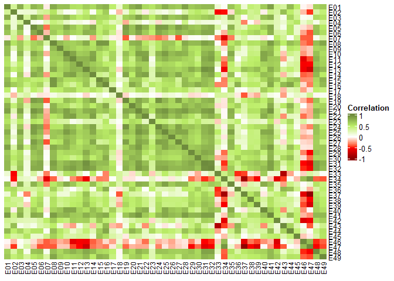

```r
col_fun = circlize::colorRamp2(c(-1,-.5,0,.5,1), c("red4","red1","white",
                                         "darkolivegreen2","darkolivegreen4"))
ComplexHeatmap::Heatmap(
  fa4$Gcor,
  col=col_fun,
  cluster_rows = F,
  cluster_columns = F,
  show_heatmap_legend = T,
  show_row_names = T,
  show_column_names = T,
  heatmap_legend_param = list(title = "Correlation"),
  row_names_gp = gpar(fontsize = 9),
  column_names_gp = gpar(fontsize = 9)
  )
```

### 2.5.5 Proportion of variance explained by each factor in each environment

```r
fa4$expvar_j[,1:10]
```

```
          E01          E02        E03       E04        E05          E06
fa1 68.714769 1.135324e+01 60.6991370  2.866303 76.9911876 74.055692250
fa2  3.694773 2.953282e+01 16.9615329  3.420820  9.5612092  0.009437758
fa3 14.756477 1.920454e+01  5.2057219 20.572703  0.2385618  0.457975472
fa4  1.051904 9.964465e-04  0.2046551 34.393146  7.5828599  9.371729895
            E07       E08       E09        E10
fa1  0.04457518 75.312868 55.672602 75.1492973
fa2 39.31048236  4.176958  1.657528 10.9599625
fa3  0.73445554 10.670319  1.952377  2.4226444
fa4 28.41174264  9.839856  7.365431  0.7851037
```

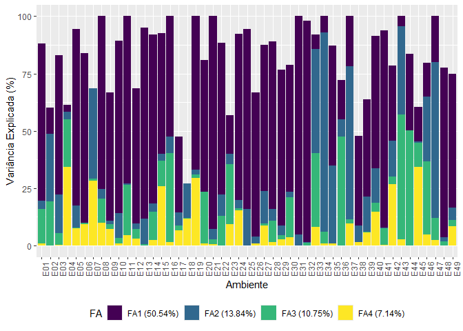

```r
data.frame(fa4$expvar_j) |>
  tibble::rownames_to_column("fa") |>
  tidyr::pivot_longer(cols = E01:E49) |>
  ggplot(aes(x = name, y = value, fill = fa)) +
  geom_bar(stat = 'identity') +
  theme(legend.position = "bottom",
        axis.text.x = element_text(angle = 90)) +
  labs(x = "Ambiente", y = "Variância Explicada (%)", fill = "FA") +
  scale_fill_viridis_d(labels = c(
    "fa1" = paste0("FA1 (",round(mean(fa4$expvar_j[1,]),2),"%)"),
    "fa2" = paste0("FA2 (",round(mean(fa4$expvar_j[2,]),2),"%)"),
    "fa3" = paste0("FA3 (",round(mean(fa4$expvar_j[3,]),2),"%)"),
    "fa4" = paste0("FA4 (",round(mean(fa4$expvar_j[4,]),2),"%)")
  ))
```

### 2.5.6 Conditional BLUPs and marginal empirical BLUPs

```r
head(fa4$blups)
```

```
  env  gen conditional std.error  marginal
1 E01 C006    5347.383  409.6906  134.8035
2 E01 C049    5566.562  110.7297  392.7423
3 E01 C054    5696.263  108.2500  540.0174
4 E01 C084    5494.399  174.7449  273.4251
5 E01 G001    4946.074  119.5839 -243.7602
6 E01 G002    5449.179  108.2943  195.2518
```

# 3 Processing of environmental data

```r
library(dplyr)
library(EnvRtype)
library(geodata)
library(raster)
library(sp)
library(sf)
```

## 3.1 Downloading and compiling data

There are several online platforms that freely provide environmental data, such as Soilgrids, Nasapower, and GAEZ. Keep in mind that, from this point on, there are two distinct procedures: obtaining environmental data for the tested environments and obtaining environmental data for the geographic coordinates (i.e., points) at which you wish to perform prediction (untested environments).

## 3.2 Tested environments

```r
data <- read.csv("data_soy.csv", stringsAsFactors = FALSE)
ambi_sel <- c("E01", "E02", "E03", "E04")
data <- data %>% filter(env %in% ambi_sel)
str(data)
```

```
'data.frame':   498 obs. of  10 variables:
 $ env  : chr  "E01" "E01" "E01" "E01" ...
 $ plant: chr  "2019-11-21" "2019-11-21" "2019-11-21" "2019-11-21" ...
 $ harv : chr  "2020-03-20" "2020-03-20" "2020-03-20" "2020-03-20" ...
 $ lat  : num  -22.2 -22.2 -22.2 -22.2 -22.2 ...
 $ lon  : num  -52.7 -52.7 -52.7 -52.7 -52.7 ...
 $ block: int  1 2 3 1 2 3 1 2 3 1 ...
 $ row  : int  32 13 13 6 18 18 27 8 8 36 ...
 $ col  : int  1 2 3 1 2 3 1 2 3 1 ...
 $ gen  : chr  "G001" "G001" "G001" "G002" ...
 $ yield: num  5525 4380 4795 5860 5185 ...
```

The get_weather() function from the EnvRtype package downloads daily environmental data from the Nasapower database according to the planting and harvesting dates. After obtaining the climatic data, we can use other functions such as param_atmospheric(), param_temperature(), and param_radiation() to process them into derived environmental covariates.

The arguments Tbase1 and Tbase2 in param_temperature() refer, respectively, to the minimum and maximum cardinal temperatures. The parameters Topt1 and Topt2 correspond, respectively, to the lower and upper temperature limits for phenological development. These values are species-dependent. See Costa-Neto et al. (2021) for more details.

```r
coords = unique(data[,c('env', 'lat', 'lon', 'plant', 'harv')])


covamb = EnvRtype::get_weather(env.id = coords$env,
lat = coords$lat,
lon = coords$lon,
start.day = coords$plant,
end.day = coords$harv)


covamb = EnvRtype::param_temperature(env.data = covamb, Tbase1 = 8, Tbase2 = 45,
Topt1 = 30, Topt2 = 35, merge = T)
```

```
----------------------------------------------------------------------
Growing Degree Day (GDD,oC/day)
Effect of temperature on radiation use efficiency (FRUE, from 0 to 1)
Daily Temperature Range, (T2M_RANGE, oC day)
----------------------------------------------------------------------
```

```r
covamb = EnvRtype::param_radiation(env.data = covamb, merge = T)
```

```
----------------------------------------------------------------------
Using NASA POWER API outputs to compute:
Extraterrestrial radiation (RTA, MJ/m^2/day)
Daylight hours (N, hours)
Actual duration of sunshine (n, hours)
----------------------------------------------------------------------
```

```r
covamb = EnvRtype::param_atmospheric(env.data = covamb, merge = T)
```

```
----------------------------------------------------------------------
Slope of saturation vapour pressure curve (SPV, in kPa.Celsius)
Vapour pressure deficit (VPD, in kPa)
Potential Evapotranspiration (ETP, in mm.day)
Deficit by Precipitation - ETP (PETP, in mm.day)
----------------------------------------------------------------------
```

We can also obtain environmental covariates related to soil from the Soilgrids platform using the soil_world() function from the geodata package. The data will be downloaded as rasters (.tif).

```r
geodata::soil_world(var = 'bdod', depth = 15, stat = 'mean', path = 'Rasters')
```

```
class       : SpatRaster
size        : 18000, 43200, 1  (nrow, ncol, nlyr)
resolution  : 0.008333333, 0.008333333  (x, y)
extent      : -180, 180, -60, 90  (xmin, xmax, ymin, ymax)
coord. ref. : lon/lat WGS 84 (EPSG:4326)
source      : bdod_5-15cm_mean_30s.tif
name        : bdod_5-15cm
min value   :         0.2
max value   :         1.8
```

```r
# geodata::soil_world(var = 'clay', depth = 15, stat = 'mean', path = 'Rasters')
# geodata::soil_world(var = 'nitrogen', depth = 15, stat = 'mean', path = 'Rasters')
# geodata::soil_world(var = 'phh2o', depth = 15, stat = 'mean', path = 'Rasters')
# geodata::soil_world(var = 'sand', depth = 15, stat = 'mean', path = 'Rasters')
# geodata::soil_world(var = 'silt', depth = 15, stat = 'mean', path = 'Rasters')
# geodata::soil_world(var = 'soc', depth = 15, stat = 'mean', path = 'Rasters')
# geodata::soil_world(var = 'cfvo', depth = 15, stat = 'mean', path = 'Rasters')
# geodata::soil_world(var = 'ocd', depth = 15, stat = 'mean', path = 'Rasters')
```

Elevation data can also be obtained from the geodata package. In addition, we manually downloaded rasters from the platform of Lembrechts et al. (2022) referring to mean soil temperature, isothermality, temperature seasonality, and mean daily thermal amplitude. Since trials were conducted between October and March (the first soybean season in Brazil), we downloaded only the rasters corresponding to this interval.

```r
geodata::elevation_30s(country = 'BRA', path = 'Rasters')
```

```
class       : SpatRaster
size        : 4716, 5448, 1  (nrow, ncol, nlyr)
resolution  : 0.008333333, 0.008333333  (x, y)
extent      : -74.1, -28.7, -33.9, 5.4  (xmin, xmax, ymin, ymax)
coord. ref. : lon/lat WGS 84 (EPSG:4326)
source      : BRA_elv_msk.tif
name        : BRA_elv_msk
min value   :        -155
max value   :        2703
```

Finally, we can use the extract_GIS() function from the EnvRtype package to extract the data for the corresponding coordinates and then merge the climatic and soil covariates.

```r
rastlist = list.files(path = 'Rasters/soil_world', pattern = '.tif', full.names = T)
rastlist = c(rastlist, list.files(path = 'Rasters', pattern = ".tif", full.names = T))
namerasts = c('bdod','alt')
soil = coords
for(i in 1:length(rastlist)){
raster_file <- raster::raster(rastlist[i])
soil <- dplyr::left_join(
soil,
EnvRtype::extract_GIS(covraster = raster_file, Latitude = 'lat',
Longitude = 'lon', name.out = namerasts[i],
env.data = coords, env.id = 'env'))}
```

```r
covamb = left_join(covamb, soil[,-(2:5)], by = c('env'))
str(covamb)
```

```
'data.frame':   484 obs. of  44 variables:
 $ env               : chr  "E01" "E01" "E01" "E01" ...
 $ LON               : num  -52.7 -52.7 -52.7 -52.7 -52.7 ...
 $ LAT               : num  -22.2 -22.2 -22.2 -22.2 -22.2 ...
 $ DOY               : int  325 326 327 328 329 330 331 332 333 334 ...
 $ YYYYMMDD          : Date, format: "2019-11-21" "2019-11-22" ...
 $ daysFromStart     : int  1 2 3 4 5 6 7 8 9 10 ...
 $ T2M               : num  29.7 30.6 31 28.4 27.8 ...
 $ T2M_MAX           : num  37.1 38.2 38.6 35 35.4 ...
 $ T2M_MIN           : num  23.6 23.2 23.7 22.1 21.5 ...
 $ T2MDEW            : num  18.7 19.3 19.3 18.9 16.6 ...
 $ ALLSKY_SFC_LW_DWN : num  35.4 35.9 37.7 36.5 35.2 ...
 $ ALLSKY_SFC_SW_DWN : num  27.8 29.6 20.2 25 28.7 ...
 $ ALLSKY_SFC_SW_DNI : num  28.9 30.8 13.3 17.2 26.7 ...
 $ ALLSKY_SFC_PAR_TOT: num  12.84 13.73 9.54 11.62 13.22 ...
```

[output cut: 30 more lines]

```r
# saveRDS(covamb, file = "saves/covamb.RDS")
rm(list=ls())
```

## 3.3 Untested environments

Up to this point, we have obtained only environmental data for the observed target population of environments (TPE). In this section, we will obtain the environmental data needed to predict the performance of selection candidates in untested environments, from several geographic coordinates.

The first step is to obtain the coordinates, which can be done using shapefiles freely available on various platforms. For example, in Brazil, the Brazilian Institute of Geography and Statistics (IBGE) provides shapefiles with different levels of detail on administrative boundaries (from municipalities to the entire country). Another useful way of obtaining shapefiles is through the gadm() function of the geodata package.

It is important to consider how you want to sample the breeding region. Here, we chose to sample coordinates within each municipality to properly represent the whole area. Thus, first, it is necessary to extract the coordinates of each municipality.

```r
br_mun    <- raster::shapefile("BR_Municipios_2021/BR_Municipios_2021.shp")
br_mun.sf <- st_read( "BR_Municipios_2021/BR_Municipios_2021.shp", quiet = TRUE)
```

The object containing these coordinates allows us to randomly sample points from each municipality for prediction purposes. After obtaining the geographic coordinates, we will randomly sample two points per municipality to carry out predictions.

```r
br_coord = as.data.frame(
raster::coordinates(raster::raster('Rasters/elevation/BRA_elv_msk.tif')))
```

```r
mun = br_mun[br_mun$SIGLA == 'RR',]
mun.sf = br_mun.sf[br_mun.sf$SIGLA == "RR", ]
mun_coords = list()
for (i in mun$NM_MUN) {
coord = dplyr::filter(br_coord, x > mun[mun$NM_MUN == i,]@bbox['x','min'] &
x < mun[mun$NM_MUN == i,]@bbox['x','max'] &
y > mun[mun$NM_MUN == i,]@bbox['y','min'] &
y < mun[mun$NM_MUN == i,]@bbox['y','max'])
pts = unique(do.call(rbind, mun.sf[mun.sf$NM_MUN == i,]$geometry[[1]][[1]]))
pts = as.data.frame(pts)
colnames(pts) = c('x','y')
coord$filt = sp::point.in.polygon(coord$x, coord$y, pts$x, pts$y)
if(all(coord$filt == 0)){
cat('I was at', i, '-', 'RR', ', but found no points \n')
next
}
coord = coord[which(coord$filt == 1),]
coord = subset(coord, select = -filt)
coord$mun = i
coord$est = 'RR'
mun_coords[[i]] = coord
rm(coord, pts)
cat('I am at', i, '-', 'RR', '\n')
}
```

```
I am at Amajari - RR
I am at Alto Alegre - RR
I am at Boa Vista - RR
I am at Bonfim - RR
I am at Cantá - RR
I am at Caracaraí - RR
I am at Caroebe - RR
I am at Iracema - RR
I am at Mucajaí - RR
I am at Normandia - RR
I am at Pacaraima - RR
I am at Rorainópolis - RR
I am at São João da Baliza - RR
I am at São Luiz - RR
I am at Uiramutã - RR
```

```r
mun.xy = do.call(rbind, mun_coords)
colnames(mun.xy) = c('lon', 'lat', 'mun', 'sta')
rm(mun, mun_coords)
```

```r
set.seed(100)
samp = mun.xy %>% dplyr::group_by(mun) %>% dplyr::slice_sample(n = 2)
samp$env = paste0("P", 1:nrow(samp))
```

Next, we can download the environmental covariates. To do this, we modified the original functions of the EnvRtype package to download monthly averages instead of daily averages. This allows us to extract and process climatic variables. Soil covariates are obtained using the same procedure as before. Finally, the climate and soil covariates are merged to compose the dataset for untested environments.

```r
source("https://raw.githubusercontent.com/saulo-chaves/May_b_useful/main/get_weather2")
```

```r
covamb_pred = get_weather2(env.id = samp$env[1:2], lat = samp$lat[1:2],
lon = samp$lon[1:2], start.year = '2000',
end.year = '2021', parallel = T)
```

```
------------------------------------------------
ATTENTION: This function requires internet access
------------------------------------------------
Connecting to the NASA POWER API Client, Sparks et al 2018
https://docs.ropensci.org/nasapower
------------------------------------------------
```

```
NASA POWER: Done!
```

```r
covamb_pred = EnvRtype::extract_GIS(covraster = raster('Rasters/BRA_elv_msk.tif'),
Latitude = 'LAT', name.out = 'ALT',
Longitude = 'LON', env.data = covamb_pred,
env.id = 'env')
Tfun = c(8, 45, 30, 35)
names(Tfun) = c('Tbase1', 'Tbase2', 'Topt1', 'Topt2')
covamb_pred = covamb_pred |> dplyr::select(env, ALT, LON, LAT, PARAMETER, YEAR,
OCT, NOV, DEC, JAN, FEB, MAR) |>
tidyr::pivot_longer(cols = OCT:MAR, names_to = 'MONTH') |>
tidyr::pivot_wider(names_from = PARAMETER, values_from = value) |>
dplyr::mutate(
T2RANGE = T2M_MAX - T2M_MIN
) |>
dplyr::mutate(
FRUE = F.RUE.Temperature(Tbase1 = Tfun['Tbase1'], Tmed = T2M,
Tbase2 = Tfun['Tbase2'], Topt1 = Tfun['Topt1'],
Topt2 = Tfun['Topt2']),
GDD = ((adjust_for_Tbase2(adjust_for_Tbase(T2M_MAX, Tfun['Tbase1']),
Tfun['Tbase2']) +
adjust_for_Tbase2(adjust_for_Tbase(T2M_MIN, Tfun['Tbase1']),
Tfun['Tbase2']))/2 -
Tfun['Tbase1']),
VPD = ((teten(T2M_MIN) + teten(T2M_MAX)/2)) - teten(T2MDEW),
SPV = 4098 * (0.6108 * exp((17.27 * T2M)/(T2M + 237.3)))/(T2M + 237.2)^2
) |>
dplyr::mutate(
ETP = EToPT(alfa = 1.26, Srad = ALLSKY_SFC_SW_DWN, slope = SPV,
psyc = psyco(AtmP(elevation = ALT)))
) |>
dplyr::mutate(PETP = PRECTOTCORR - ETP)
```

```r
rastlist = list.files(path = 'Rasters/soil_world', pattern = '.tif', full.names = T)
namerasts = c('bdod')
soil = data.frame(samp)
for(i in 1:length(rastlist)){
raster_file <- raster::raster(rastlist[i])
soil <- dplyr::left_join(soil,
EnvRtype::extract_GIS(covraster = raster_file, Latitude = 'lat',
Longitude = 'lon', name.out = namerasts[i],
env.data = data.frame(samp),
env.id = 'env'),
by = c("env","lon", "lat", "mun", "sta"))}
```

```r
covamb_pred = merge(covamb_pred, soil)
covamb_pred = covamb_pred |> dplyr::select(-lon, -lat) |>
dplyr::relocate(sta, mun, .before = env) |>
dplyr::relocate(YEAR, MONTH, ALT, LON, LAT, .before = T2M)
str(covamb_pred)
```

```
'data.frame':   264 obs. of  25 variables:
 $ sta              : chr  "RR" "RR" "RR" "RR" ...
 $ mun              : chr  "Alto Alegre" "Alto Alegre" "Alto Alegre" "Alto Alegre" ...
 $ env              : Factor w/ 2 levels "P1","P2": 1 1 1 1 1 1 1 1 1 1 ...
 $ ALLSKY_SFC_LW_DWN: num  36 36.1 35.9 36.3 35.5 ...
 $ ALLSKY_SFC_SW_DWN: num  20.2 17.4 18.1 16.9 19.4 ...
 $ PRECTOTCORR      : num  4.54 5.09 1.77 6.49 4.79 5.97 3.6 1.78 4.76 1.14 ...
 $ RH2M             : num  90.9 91.2 89 91.8 89.4 ...
 $ YEAR             : num  2000 2000 2000 2000 2000 ...
 $ MONTH            : chr  "OCT" "NOV" "DEC" "JAN" ...
 $ ALT              : num  332 332 332 332 332 332 332 332 332 332 ...
 $ LON              : num  -62.3 -62.3 -62.3 -62.3 -62.3 ...
 $ LAT              : num  2.95 2.95 2.95 2.95 2.95 ...
 $ T2M              : num  24.3 24.3 23.8 23.3 23 ...
 $ T2MDEW           : num  22.7 22.7 21.8 21.9 21.1 ...
 $ T2M_MAX          : num  29.2 29 28.1 28 27.9 ...
 $ T2M_MIN          : num  19.7 20.4 19.4 19.8 17.4 ...
 $ WS2M             : num  0.2 0.18 0.17 0.15 0.16 0.15 0.18 0.14 0.13 0.13 ...
 $ T2RANGE          : num  9.48 8.61 8.64 8.24 10.47 ...
 $ FRUE             : num  0.74 0.74 0.718 0.696 0.682 ...
 $ GDD              : num  16.5 16.7 15.8 15.9 14.6 ...
 $ VPD              : num  1.57 1.62 1.54 1.57 1.36 ...
 $ SPV              : num  0.182 0.182 0.177 0.173 0.17 ...
 $ ETP              : num  9.13 7.83 8.14 7.6 8.71 ...
 $ PETP             : num  -4.59 -2.74 -6.37 -1.11 -3.92 ...
 $ bdod             : num  1.1 1.1 1.1 1.1 1.1 ...
```

```r
# saveRDS(covamb_pred, file = "saves/covamb_pred.RDS")
rm(list=ls())
```

# 4 GIS-FA prediction

```r
library(tidyverse)
library(gghighlight)
library(ggrepel)
library(ggpubr)
library(ggspatial)
library(circlize)
require(pls)
library(raster)
library(sf)
library(spatstat)
library(geodata)
library(parallel)
library(doParallel)
library(foreach)
library(dplyr)
```

## 4.1 Databases

For the next analyses, we will need the phenotypic dataset, along with all the information obtained on the first steps of the course: the fitted model and the extracted environmental variables.

```r
data <- read.csv("data_soy.csv", stringsAsFactors = FALSE)

data = transform(data,
                 gen = factor(gen),
                 block = factor(block),
                 env = factor(env))
num.env = nlevels(data$env)
num.gen = nlevels(data$gen)
name.env = levels(data$env)
name.gen = levels(data$gen)


fa4 = readRDS("fa4.RDS")

covamb = readRDS("covamb.RDS")

covamb_pred = readRDS("covamb_pred.RDS")
```

At this stage, we build the matrices that contain the mean of each environmental covariate for each environment.

```r
matcovamb = subset(covamb, select = c(-YEAR, -MM, -DD, -DOY, -YYYYMMDD,
                                         -daysFromStart, -n, -N, -RTA))
matcovamb = matcovamb |> dplyr::reframe(across(LON:soiltemp, mean), .by = 'env')
matcovamb = tibble::column_to_rownames(matcovamb, var = 'env')

covamb_pred = covamb_pred |>
  dplyr::filter(YEAR != 2000 | !MONTH %in% c('JAN','FEB','MAR')) |>
  dplyr::filter(YEAR != 2021 | !MONTH %in% c('OCT','NOV','DEC')) |>
  dplyr::select(-YEAR, -MONTH) |>
  dplyr::reframe(across(ALT:soiltemp, mean), .by = c(mun, env)) |>
  dplyr::rename(T2M_RANGE = T2RANGE, PRECTOT = PRECTOTCORR)
```

## 4.2 Environmental Similarity

Prediction will be more accurate in environments where trials were conducted, since it is possible to observe the relationship between the selection candidates and the environmental characteristics. However, we cannot have the same certainty about prediction reliability for untested environments.

A metric that can give us an indication of this reliability is environmental similarity. If an unobserved environment presents environmental conditions similar to those of an observed environment, it is likely that the prediction for it will be more reliable.

To calculate environmental similarity, we must first order the columns of the matrices containing the environmental information of observed and unobserved environments so that they follow the same order.

```r
matcovamb = matcovamb[, sort(colnames(matcovamb))]


matcovamb_pred = covamb_pred |>
  tibble::column_to_rownames('env') |>
  dplyr::select(-mun)
matcovamb_pred = matcovamb_pred[, sort(colnames(matcovamb_pred))]
matcovamb_pred = as.matrix(matcovamb_pred)


all(tolower(colnames(matcovamb_pred)) == tolower(colnames(matcovamb)))
```

```
[1] TRUE
```

Next, the Euclidean distances between observed and unobserved environments are calculated to quantify environmental similarity. The distance matrix is then transformed into long format and divided into data frames stored in a list. In total, there will be 49 data frames, each representing an observed environment of the TPE.

```r
eucl = as.matrix(pdist::pdist(scale(matcovamb), scale(matcovamb_pred)))
rownames(eucl) = rownames(matcovamb)
colnames(eucl) = rownames(matcovamb_pred)
```

```r
dist.env = lapply(apply(eucl, 1, function(x) reshape2::melt(x)),
       function(x) x |>
         dplyr::rename(dist = value) |>
         tibble::rownames_to_column('point') |>
         dplyr::left_join(covamb_pred[,c('env', 'LON', 'LAT')],
                   by = c('point' = 'env')))
rm(eucl)
```

Each data frame contains 3,891 sampled points for prediction. However, remember that our goal is to predict genotype performance across the entire state. In other words, we need to expand the results to every sampled point through an interpolation process. Here, we use the Inverse Distance Weighted (IDW) interpolation method.

To interpolate, we must first define the observation window. This window is defined by a bounding box corresponding to the administrative boundaries of the state. These limits are extracted from a shapefile provided by IBGE.

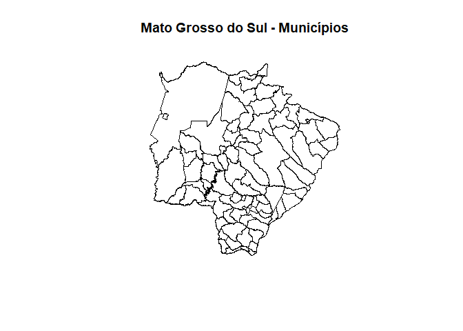

```r
br_est <- st_read("BR_Municipios_2023/BR_Municipios_2023.shp")
MS_sf <- br_est %>% filter(NM_UF == "Mato Grosso do Sul")

plot(st_geometry(MS_sf), main = "Mato Grosso do Sul - Municípios")
```

```r
MS_pol <- br_est[br_est$NM_UF == "Mato Grosso do Sul", ]

bbox_ms <- sf::st_bbox(MS_sf)

obs_window <- spatstat.geom::owin(
  xrange = c(bbox_ms["xmin"], bbox_ms["xmax"]),
  yrange = c(bbox_ms["ymin"], bbox_ms["ymax"])
)
```

After defining the observation window, we perform an iterative process to determine the optimal value of the power parameter used in the IDW interpolation weighting. The optimal parameter is the one that minimizes the mean squared prediction error (MSPE). Once defined, interpolation is carried out with this parameter. Parallel processing is employed to accelerate computation time.

```r
cl = parallel::makeCluster(parallel::detectCores(logical = F)-2)
parallel::clusterEvalQ(cl, {library(spatstat)
                            library(raster)
                            library(sf)})
parallel::clusterExport(cl, varlist = c('obs_window', 'MS_sf'))

dist.list = parallel::parLapply(cl = cl, dist.env, function(x){

  ppp_test = spatstat.geom::ppp(x = x$LON, y = x$LAT,
                 marks = x$dist, window = obs_window)

  powers <- seq(1, 2, 1)
  mse_result <- NULL
  for(power in powers){
    CV_idw <- spatstat.explore::idw(ppp_test, power=power, at="points")
    mse_result <- c(mse_result, mean((ppp_test$marks-CV_idw)^2, na.rm=T))
  }
  optimal_power <- powers[which.min(mse_result)]

  tr_idw = spatstat.explore::idw(ppp_test, power = optimal_power, at = 'pixels')

  idw_raster = as(raster::mask(raster::raster(tr_idw, crs = crs(br_est)), MS_sf),
                  "SpatialPixelsDataFrame")

  idw_raster.df = as.data.frame(idw_raster)
})
parallel::stopCluster(cl)
rm(cl)
```

```r
mindist = apply(do.call(cbind, lapply(dist.list, function(x) x[,-c(2,3)])),
                1, function(x) x[which.min(x)])
```

Finally, we can construct a map to illustrate how reliable the prediction will be throughout the state.

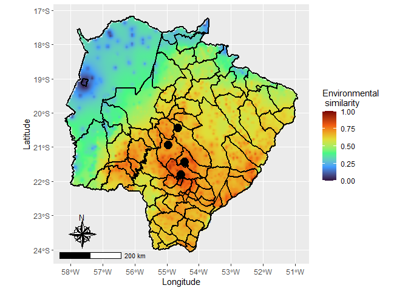

```r
cbind(dist.list$E01[,-1],
      layer = abs((mindist - min(mindist))/(max(mindist) - min(mindist))-1)) |>
  ggplot() +
  ggspatial::annotation_scale(location = "bl", width_hint = 0.3) +
  ggspatial::annotation_north_arrow(location = "bl", which_north = "true",
                         pad_x = unit(0.5,"cm"), pad_y = unit(0.7,"cm"),
                         style = ggspatial::north_arrow_nautical())+
  geom_raster(aes(x = x, y = y , fill = layer), interpolate = T) +
  geom_sf(data = MS_sf, fill = NA, linewidth = 1, color = "black")  +
  labs(x = 'Longitude', y = 'Latitude', fill = 'Environmental \n similarity') +
  scale_fill_viridis_c(option = 'turbo', direction = 1,
                       limits = c(0, 1)) +
  theme(legend.position = 'right') +
  geom_point(
    data = data.frame("lat" = c(-21.434,-20.442,-21.801,-20.931),
                      "lon" = c(-54.438,-54.646,-54.546,-54.961)),
    aes(x = lon, y = lat, size = 1.2), show.legend = F, color = 'black',
  )
```

```r
rm(dist.list, dist.env)
```

## 4.3 Prediction via PLS

After obtaining the environmental data and factor loadings, it is time to predict the expected performance of the selection candidates in untested environments using the Partial Least Squares (PLS) method. Initially, we train a model with the environmental characteristics to predict the factor loadings for all environments (observed and unobserved). With the predicted loadings and the scores previously estimated for each genotype in the FA model, we can predict the BLUPs of the genotypes in untested environments.

The first step is to fit the PLS model using the environmental data. We must define the optimal number of components for prediction through leave-one-out cross-validation.

```r
rows <- paste0("E", sprintf("%02d", 1:49))
matcovamb_subset <- matcovamb[rownames(matcovamb) %in% rows, ]
data.pls.lamb <- data.frame(lambda = I(fa4$rot.loads),
                            CovAmb = I(scale(as.matrix(matcovamb_subset))))

pls1.lamb = pls::plsr(lambda ~ CovAmb, validation = 'CV', data = data.pls.lamb)
```

```r
ncomp = list()
for (j in 1:pls1.lamb$ncomp) {
  acc_eblup = vector()
  acc_lamb = vector()
  for (i in rownames(matcovamb)) {
    train = data.pls.lamb[rownames(data.pls.lamb) != i,]
    test = data.pls.lamb[rownames(data.pls.lamb) == i,]

    cvloo = pls::plsr(lambda ~ CovAmb, validation = 'CV', data = train,
                 ncomp = j)

    acc_lamb = c(
      acc_lamb,
      cor(
        t(test$CovAmb %*% coef(cvloo, intercept = T)[-1,,1] +
            coef(cvloo, intercept = T)[1,,1]),
        t(test$lambda)
      )
    )

    acc_eblup = c(
      acc_eblup,
      cor(
        t(tcrossprod(
          test$CovAmb %*% coef(cvloo, intercept = T)[-1,,1] +
            coef(cvloo, intercept = T)[1,,1],
          fa4$rot.scores
        )),
        fa4$blups[fa4$blups$env == i, 'marginal'], method = 'spearman'
      )
    )
    rm(cvloo, train, test)
  }
  ncomp[[j]] = data.frame(ncomp = j, lambda = mean(acc_lamb),
                          eblup = mean(acc_eblup))
}
cv.results = do.call(rbind, ncomp)

cv.results[which.max(cv.results$lambda),]
```

```
  ncomp    lambda     eblup
8     8 0.5722463 0.7399924
```

```r
cv.results[which.max(cv.results$eblup),]
```

```
  ncomp    lambda     eblup
3     3 0.5603842 0.7436089
```

The PLS model with three components provided the best results. We then fit the final prediction model with this configuration.

```r
pls2.lamb = pls::plsr(lambda ~ CovAmb, validation = 'CV', data = data.pls.lamb,
                 ncomp = 3)
pls::explvar(pls2.lamb)
```

```
  Comp 1   Comp 2   Comp 3
33.20491 18.36629 10.00163
```

## 4.4 BLUPs prediction in Untested Environments

Next, we predict the phenotypic performance of the 182 genotypes in untested environments using the GIS-FA model. The first step is to extract the regression coefficients from the fitted PLS model.

```r
coef_pls = coef(pls2.lamb, intercept = T)[,,1]
```

Using the environmental data of the unobserved environments, we then predict their factor loadings.

```r
matcovamb = matcovamb[, sort(colnames(matcovamb))]

matcovamb_pred = covamb_pred |>
  tibble::column_to_rownames('env') |>
  dplyr::select(-mun)
matcovamb_pred = matcovamb_pred[, sort(colnames(matcovamb_pred))]
matcovamb_pred = as.matrix(matcovamb_pred)

all(tolower(colnames(matcovamb_pred)) == tolower(colnames(matcovamb)))
```

```
[1] TRUE
```

```r
pred_lambda = scale(matcovamb_pred) %*% coef_pls[-1, ]

pred_lambda = cbind(
  fa1 = pred_lambda[,'fa1'] + coef_pls["(Intercept)", "fa1"],
  fa2 = pred_lambda[,'fa2'] + coef_pls["(Intercept)", "fa2"],
  fa3 = pred_lambda[,'fa3'] + coef_pls["(Intercept)", "fa3"],
  fa4 = pred_lambda[,'fa4'] + coef_pls["(Intercept)", "fa4"]
)

rownames(pred_lambda) = rownames(matcovamb_pred)
```

Finally, we combine the multiple regression with the FA model (i.e., GIS-FA) to predict the eBLUP values in the unobserved environments.

```r
EBLUPs_pred = (as.matrix(pred_lambda[,'fa1']) %*% fa4$rot.scores[,'fa1'] +
              as.matrix(pred_lambda[,'fa2']) %*% fa4$rot.scores[,'fa2'] +
              as.matrix(pred_lambda[,'fa3']) %*% fa4$rot.scores[,'fa3'] +
              as.matrix(pred_lambda[,'fa4']) %*% fa4$rot.scores[,'fa4'] +
              mean(data$yield, na.rm = T))

colnames(EBLUPs_pred) = levels(data$gen)
```

# 5 Visualization through Maps

After performing the predictions, we can construct thematic maps to assist in visualization.

## 5.1 Interpolation

Predictions were made only for sampled points. To expand them across the entire state, an interpolation process is required. This step is performed using IDW interpolation, as described earlier.

```r
pred.list = lapply(apply(EBLUPs_pred, 2, function(x) reshape2::melt(x)),
                          function(x) x |>
                     dplyr::rename(blup = value) |>
                     tibble::rownames_to_column('point') |>
                     dplyr::left_join(
                       unique(covamb_pred[,c('env', 'LON', 'LAT')]),
                                      by = c('point' = 'env'))
                   )


cl = parallel::makeCluster(parallel::detectCores(logical = F)-1)
parallel::clusterEvalQ(cl, {library(spatstat)
                            library(raster)
                            library(sf)})
parallel::clusterExport(cl, varlist = c('obs_window', 'MS_sf'))

pred.list = parallel::parLapply(cl, pred.list, function(x){

  ppp_test = spatstat.geom::ppp(x = x[which(!is.na(x$blup)),'LON'],
                 y = x[which(!is.na(x$blup)),'LAT'],
                 marks = na.exclude(x$blup), window = obs_window)

  powers <- seq(1, 2, 1)
  mse_result <- NULL
  for(power in powers){
    CV_idw <- spatstat.explore::idw(ppp_test, power=power, at="points")
    mse_result <- c(mse_result, mean((ppp_test$marks-CV_idw)^2, na.rm=T))
  }
  optimal_power <- powers[which.min(mse_result)]

  tr_idw = spatstat.explore::idw(ppp_test, power = optimal_power, at = 'pixels')

  idw_raster = as(raster::mask(raster::raster(tr_idw, crs = crs(br_est)), MS_sf),
                  "SpatialPixelsDataFrame")

  idw_raster.df = as.data.frame(idw_raster)
})
parallel::stopCluster(cl)
```

## 5.2 which-won-where

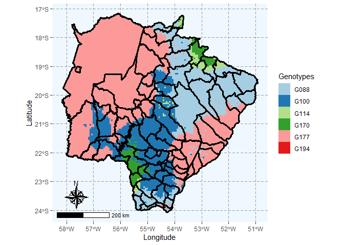

```r
cbind(pred.list[[1]][,c('x','y')],
            winner = apply(cbind(pred.list[[1]][,c('x','y')],
                do.call(cbind, lapply(pred.list, function(x) x[,'layer']))),
          1, function(x) names(which(x == max(x, na.rm=T))), simplify = T)) |>
  ggplot() +
  ggspatial::annotation_scale(location = "bl", width_hint = 0.3) +
  ggspatial::annotation_north_arrow(location = "bl", which_north = "true",
                         pad_x = unit(0.5,"cm"), pad_y = unit(0.7,"cm"),
                         style = ggspatial::north_arrow_nautical())+
  geom_raster(aes(x = x, y = y , fill = winner))+
  geom_sf(data= MS_sf, fill = NA, linewidth = 1.2, color = 'black')+
  labs(x = 'Longitude', y = 'Latitude',
       fill = "Genotypes",color = "")+
  theme(panel.grid.major = element_line(color = gray(.6), linetype = "dashed",
                                        linewidth = 0.3),
        panel.background = element_rect(fill = "aliceblue"),
        legend.position = 'right',
        legend.spacing = unit(.02,'cm')) +
    scale_fill_brewer(type = 'qual', palette = 'Paired') +
  guides(fill = guide_legend(order = 1, override.aes = list(colour = 0)))
```

## 5.3 pairwise comparison

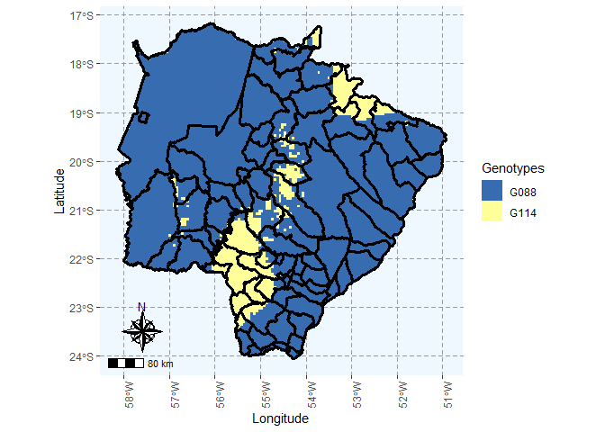

```r
cbind(pred.list[[1]][,c('x','y')],
      winner = apply(
        do.call(cbind, lapply(pred.list, function(x) x[,"layer"]))[, c("G114",
                                                                       "G088")],
        1, function(x) names(which.max(x))
      )) |>
  ggplot() +
  ggspatial::annotation_scale(location = "bl", width_hint = .1) +
  ggspatial::annotation_north_arrow(location = "bl", which_north = "true",
                         pad_x = unit(0.5,"cm"), pad_y = unit(0.7,"cm"),
                         style = ggspatial::north_arrow_nautical())+
  geom_raster(aes(x = x, y = y , fill = winner)) +
  geom_sf(data= MS_sf, fill = NA, linewidth = 1.2, color = 'black')+
  labs(x = 'Longitude', y = 'Latitude',
       fill = "Genotypes",color = "")+
  theme(panel.grid.major = element_line(color = gray(.6), linetype = "dashed",
                                        linewidth = 0.3),
        panel.background = element_rect(fill = "aliceblue"),
        legend.position = 'right',
        #legend.box.margin = margin(.05,.05,.05,.05,'cm'),
        legend.spacing = unit(.02,'cm'),
        axis.text.x = element_text(angle = 90)) +
  scale_fill_manual(values = c("G114" = "#ffff99", "G088" = "#386cb0")) +
  guides(fill = guide_legend(order = 1, override.aes = list(colour = 0)))
```

## 5.4 adaptation zones

```r
EBLUPs_pred = do.call(rbind, pred.list)  |>
  rownames_to_column('gen') |>
  separate(gen, into = c('gen', 'trash')) |>
  dplyr::select(-trash) |>
  rename(blup = layer)

str(EBLUPs_pred)
```

```
'data.frame':   1842022 obs. of  4 variables:
 $ gen : chr  "C006" "C006" "C006" "C006" ...
 $ blup: num  3527 3529 3530 3521 3523 ...
 $ x   : num  -56.2 -56.1 -56 -56.2 -56.2 ...
 $ y   : num  -17.2 -17.2 -17.2 -17.2 -17.2 ...
```

We can further classify the predicted performance of genotypes into groups to facilitate interpretation. For example, predicted yields above 4000 kg ha⁻¹ are classified as group 8, between 3750 and 4000 as group 7, and so forth. This makes it possible to assess whether a given genotype reaches a minimum performance threshold in a particular region.

```r
EBLUPs_pred = EBLUPs_pred %>% mutate(
  class = case_when(
    blup > min(blup, na.rm = T) & blup <= 2500 ~ 1,
    blup > 2500 & blup <= 2750 ~ 2,
    blup > 2750 & blup <= 3000 ~ 3,
    blup > 3000 & blup <= 3250 ~ 4,
    blup > 3250 & blup <= 3500 ~ 5,
    blup > 3500 & blup <= 3750 ~ 6,
    blup > 3750 & blup <= 4000 ~ 7,
    blup > 4000 & blup <= max(blup, na.rm = T) ~ 8
  )
)
```

Finally, we can construct adaptation maps for each genotype.

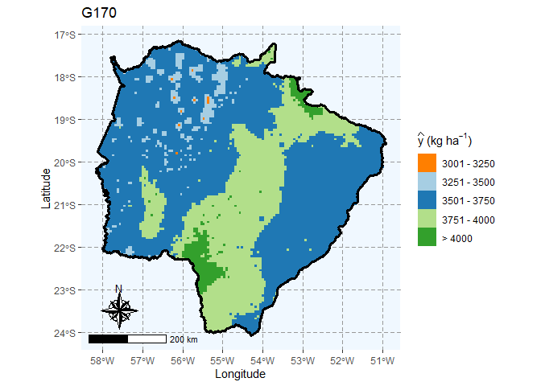

```r
br_est <- st_read("BR_Municipios_2023/BR_Municipios_2023.shp")
MS <- br_est %>% filter(NM_UF == "Mato Grosso do Sul") %>%
  st_union() %>%
  st_as_sf()

g = "G170"

EBLUPs_pred |>
  filter(gen == g) |>
  ggplot() +

  ggspatial::annotation_scale(location = "bl", width_hint = 0.3) +
  ggspatial::annotation_north_arrow(
    location = "bl", which_north = "true",
    pad_x = unit(0.5, "cm"), pad_y = unit(0.7, "cm"),
    style = ggspatial::north_arrow_nautical()
  ) +


  geom_raster(aes(x = x, y = y, fill = factor(class))) +


  geom_sf(data = MS, fill = NA, linewidth = 1.2, color = 'black') +


  labs(
    x = 'Longitude', y = 'Latitude',
    fill = expression(widehat(y)~"("*kg~ha^{-1}*")"),
    title = g
  ) +


  theme(
    panel.grid.major = element_line(color = gray(.6), linetype = "dashed", linewidth = 0.3),
    panel.background = element_rect(fill = "aliceblue"),
    legend.position = 'right',
    legend.spacing = unit(0.02, 'cm')
  ) +


  scale_fill_manual(
    values = c(
      "1" = '#e31a1c',
      "2" = '#fb9a99',
      "3" = '#fdbf6f',
      "4" = '#ff7f00',
      "5" = '#a6cee3',
      "6" = '#1f78b4',
      "7" = '#b2df8a',
      "8" = '#33a02c'
    ),
    labels = c(
      "1" = 'Non-adapted',
      "2" = '2500 - 2750',
      "3" = '2751 - 3000',
      "4" = '3001 - 3250',
      "5" = '3251 - 3500',
      "6" = '3501 - 3750',
      "7" = '3751 - 4000',
      "8" = '> 4000'
    )
  )
```